# Risk Factor Analysis

## Outcome Variable

**Outcome Variable:** stunted

## Predictor Variables

**Intervention Variable:** impsan

**Adjustment Set:**

unadjusted

## Stratifying Variables

The analysis was stratified on these variable(s):

- agecat
- studyid
- country

## Data Summary

| agecat | studyid | country | impsan | stunted | n_cell | n |
| --- | --- | --- | --- | --- | --- | --- |
| Birth | COHORTS | GUATEMALA | 1 | 0 | 42 | 491 |
| Birth | COHORTS | GUATEMALA | 1 | 1 | 3 | 491 |
| Birth | COHORTS | GUATEMALA | 0 | 0 | 416 | 491 |
| Birth | COHORTS | GUATEMALA | 0 | 1 | 30 | 491 |
| Birth | COHORTS | INDIA | 1 | 0 | 1593 | 4776 |
| Birth | COHORTS | INDIA | 1 | 1 | 174 | 4776 |
| Birth | COHORTS | INDIA | 0 | 0 | 2618 | 4776 |
| Birth | COHORTS | INDIA | 0 | 1 | 391 | 4776 |
| Birth | COHORTS | PHILIPPINES | 1 | 0 | 176 | 1191 |
| Birth | COHORTS | PHILIPPINES | 1 | 1 | 2 | 1191 |
| Birth | COHORTS | PHILIPPINES | 0 | 0 | 936 | 1191 |
| Birth | COHORTS | PHILIPPINES | 0 | 1 | 77 | 1191 |
| Birth | CONTENT | PERU | 1 | 0 | 1 | 2 |
| Birth | CONTENT | PERU | 1 | 1 | 0 | 2 |
| Birth | CONTENT | PERU | 0 | 0 | 1 | 2 |
| Birth | CONTENT | PERU | 0 | 1 | 0 | 2 |
| Birth | JiVitA-3 | BANGLADESH | 1 | 0 | 10471 | 22431 |
| Birth | JiVitA-3 | BANGLADESH | 1 | 1 | 4749 | 22431 |
| Birth | JiVitA-3 | BANGLADESH | 0 | 0 | 4577 | 22431 |
| Birth | JiVitA-3 | BANGLADESH | 0 | 1 | 2634 | 22431 |
| Birth | JiVitA-4 | BANGLADESH | 1 | 0 | 1541 | 2820 |
| Birth | JiVitA-4 | BANGLADESH | 1 | 1 | 640 | 2820 |
| Birth | JiVitA-4 | BANGLADESH | 0 | 0 | 423 | 2820 |
| Birth | JiVitA-4 | BANGLADESH | 0 | 1 | 216 | 2820 |
| Birth | MAL-ED | BANGLADESH | 1 | 0 | 147 | 213 |
| Birth | MAL-ED | BANGLADESH | 1 | 1 | 32 | 213 |
| Birth | MAL-ED | BANGLADESH | 0 | 0 | 29 | 213 |
| Birth | MAL-ED | BANGLADESH | 0 | 1 | 5 | 213 |
| Birth | MAL-ED | BRAZIL | 1 | 0 | 50 | 60 |
| Birth | MAL-ED | BRAZIL | 1 | 1 | 9 | 60 |

[output cut: 170 more lines]

The following strata were considered:

- agecat: 24 months, studyid: COHORTS, country: GUATEMALA
- agecat: 24 months, studyid: COHORTS, country: INDIA
- agecat: 24 months, studyid: COHORTS, country: PHILIPPINES
- agecat: 24 months, studyid: CONTENT, country: PERU
- agecat: 24 months, studyid: JiVitA-3, country: BANGLADESH
- agecat: 24 months, studyid: JiVitA-4, country: BANGLADESH
- agecat: 24 months, studyid: LCNI-5, country: MALAWI
- agecat: 24 months, studyid: MAL-ED, country: BANGLADESH
- agecat: 24 months, studyid: MAL-ED, country: BRAZIL
- agecat: 24 months, studyid: MAL-ED, country: INDIA
- agecat: 24 months, studyid: MAL-ED, country: NEPAL
- agecat: 24 months, studyid: MAL-ED, country: PERU
- agecat: 24 months, studyid: MAL-ED, country: SOUTH AFRICA
- agecat: 24 months, studyid: MAL-ED, country: TANZANIA, UNITED REPUBLIC OF
- agecat: 24 months, studyid: NIH-Birth, country: BANGLADESH
- agecat: 24 months, studyid: NIH-Crypto, country: BANGLADESH
- agecat: 24 months, studyid: PROVIDE, country: BANGLADESH
- agecat: 6 months, studyid: COHORTS, country: GUATEMALA
- agecat: 6 months, studyid: COHORTS, country: INDIA
- agecat: 6 months, studyid: COHORTS, country: PHILIPPINES
- agecat: 6 months, studyid: CONTENT, country: PERU
- agecat: 6 months, studyid: JiVitA-3, country: BANGLADESH
- agecat: 6 months, studyid: JiVitA-4, country: BANGLADESH
- agecat: 6 months, studyid: LCNI-5, country: MALAWI
- agecat: 6 months, studyid: MAL-ED, country: BANGLADESH
- agecat: 6 months, studyid: MAL-ED, country: BRAZIL
- agecat: 6 months, studyid: MAL-ED, country: INDIA
- agecat: 6 months, studyid: MAL-ED, country: NEPAL
- agecat: 6 months, studyid: MAL-ED, country: PERU
- agecat: 6 months, studyid: MAL-ED, country: SOUTH AFRICA
- agecat: 6 months, studyid: MAL-ED, country: TANZANIA, UNITED REPUBLIC OF
- agecat: 6 months, studyid: NIH-Birth, country: BANGLADESH
- agecat: 6 months, studyid: NIH-Crypto, country: BANGLADESH
- agecat: 6 months, studyid: PROVIDE, country: BANGLADESH
- agecat: Birth, studyid: COHORTS, country: GUATEMALA
- agecat: Birth, studyid: COHORTS, country: INDIA
- agecat: Birth, studyid: COHORTS, country: PHILIPPINES
- agecat: Birth, studyid: CONTENT, country: PERU
- agecat: Birth, studyid: JiVitA-3, country: BANGLADESH
- agecat: Birth, studyid: JiVitA-4, country: BANGLADESH
- agecat: Birth, studyid: MAL-ED, country: BANGLADESH
- agecat: Birth, studyid: MAL-ED, country: BRAZIL
- agecat: Birth, studyid: MAL-ED, country: INDIA
- agecat: Birth, studyid: MAL-ED, country: NEPAL
- agecat: Birth, studyid: MAL-ED, country: PERU
- agecat: Birth, studyid: MAL-ED, country: SOUTH AFRICA
- agecat: Birth, studyid: MAL-ED, country: TANZANIA, UNITED REPUBLIC OF
- agecat: Birth, studyid: NIH-Birth, country: BANGLADESH
- agecat: Birth, studyid: NIH-Crypto, country: BANGLADESH
- agecat: Birth, studyid: PROVIDE, country: BANGLADESH

### Dropped Strata

Some strata were dropped due to rare outcomes:

- agecat: Birth, studyid: COHORTS, country: GUATEMALA
- agecat: Birth, studyid: COHORTS, country: PHILIPPINES
- agecat: Birth, studyid: CONTENT, country: PERU
- agecat: Birth, studyid: MAL-ED, country: BRAZIL
- agecat: Birth, studyid: MAL-ED, country: INDIA
- agecat: Birth, studyid: MAL-ED, country: NEPAL
- agecat: Birth, studyid: MAL-ED, country: SOUTH AFRICA
- agecat: Birth, studyid: MAL-ED, country: TANZANIA, UNITED REPUBLIC OF
- agecat: Birth, studyid: PROVIDE, country: BANGLADESH
- agecat: 6 months, studyid: CONTENT, country: PERU
- agecat: 6 months, studyid: LCNI-5, country: MALAWI
- agecat: 6 months, studyid: MAL-ED, country: BRAZIL
- agecat: 6 months, studyid: MAL-ED, country: NEPAL
- agecat: 6 months, studyid: MAL-ED, country: SOUTH AFRICA
- agecat: 6 months, studyid: MAL-ED, country: TANZANIA, UNITED REPUBLIC OF
- agecat: 6 months, studyid: PROVIDE, country: BANGLADESH
- agecat: 24 months, studyid: CONTENT, country: PERU
- agecat: 24 months, studyid: LCNI-5, country: MALAWI
- agecat: 24 months, studyid: MAL-ED, country: BRAZIL
- agecat: 24 months, studyid: MAL-ED, country: NEPAL
- agecat: 24 months, studyid: MAL-ED, country: SOUTH AFRICA
- agecat: 24 months, studyid: MAL-ED, country: TANZANIA, UNITED REPUBLIC OF
- agecat: 24 months, studyid: PROVIDE, country: BANGLADESH

## Methods Detail

We’re interested in the causal parameters $E[Y_a]$ for all values of $a \in \mathcal{A}$. These parameters represent the mean outcome if, possibly contrary to fact, we intervened to set all units to have $A=a$. Under the randomization and positivity assumptions, these are identified by the statistical parameters $\psi_a=E_W[E_{Y|A,W}(Y|A=a,W)]$. In addition, we’re interested in the mean of $Y$, $E[Y]$ under no intervention (the observed mean). We will estimate these parameters by using SuperLearner to fit the relevant likelihood factors – $E_{Y|A,W}(Y|A=a,W)$ and $p(A=a|W)$, and then updating our likelihood fit using a joint TMLE.

For unadjusted analyses ($W=\{\}$), initial likelihoods were estimated using Lrnr_glm to estimate the simple $E(Y|A)$ and Lrnr_mean to estimate $p(A)$. For adjusted analyses, a small library containing Lrnr_glmnet, Lrnr_xgboost, and Lrnr_mean was used.

Having estimated these parameters, we will then use the delta method to estimate relative risks and attributable risks relative to a prespecified baseline level of $A$.

# Results Detail

## Results Plots

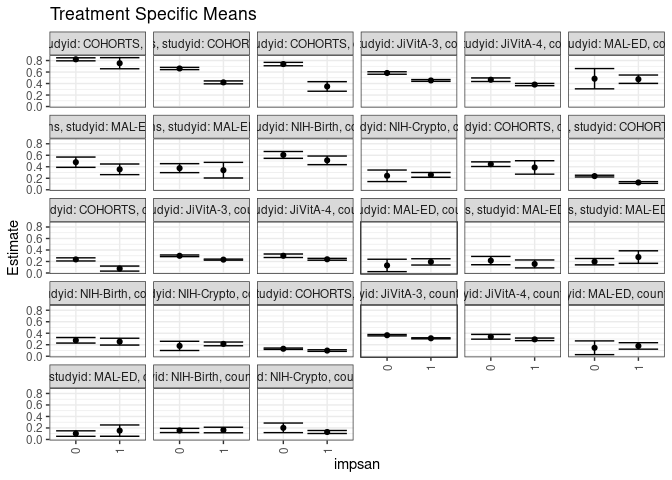

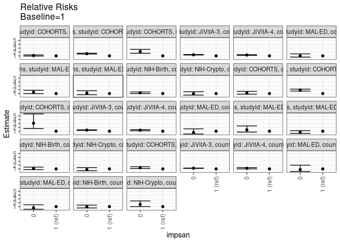

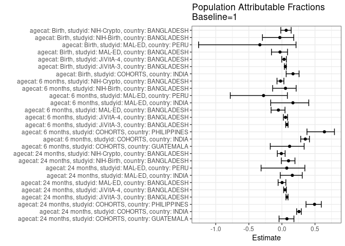

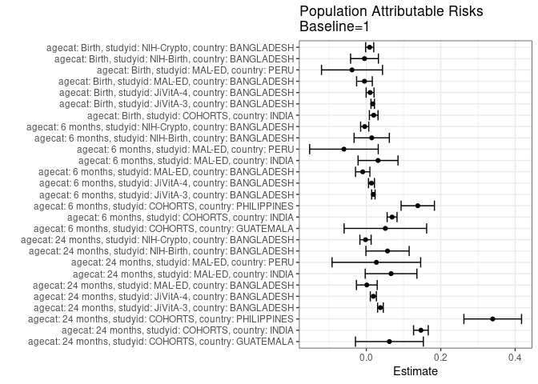

## Results Table

### Parameter: TSM

| agecat | studyid | country | intervention_level | baseline_level | estimate | ci_lower | ci_upper |
| --- | --- | --- | --- | --- | --- | --- | --- |
| Birth | COHORTS | INDIA | 1 | NA | 0.0984720 | 0.0845782 | 0.1123658 |
| Birth | COHORTS | INDIA | 0 | NA | 0.1299435 | 0.1179282 | 0.1419588 |
| Birth | JiVitA-3 | BANGLADESH | 1 | NA | 0.3120237 | 0.3032546 | 0.3207927 |
| Birth | JiVitA-3 | BANGLADESH | 0 | NA | 0.3652753 | 0.3532469 | 0.3773037 |
| Birth | JiVitA-4 | BANGLADESH | 1 | NA | 0.2934434 | 0.2709323 | 0.3159544 |
| Birth | JiVitA-4 | BANGLADESH | 0 | NA | 0.3380282 | 0.2966131 | 0.3794432 |
| Birth | MAL-ED | BANGLADESH | 1 | NA | 0.1787709 | 0.1225078 | 0.2350341 |
| Birth | MAL-ED | BANGLADESH | 0 | NA | 0.1470588 | 0.0277327 | 0.2663850 |
| Birth | MAL-ED | PERU | 1 | NA | 0.1538462 | 0.0555445 | 0.2521478 |
| Birth | MAL-ED | PERU | 0 | NA | 0.1025641 | 0.0548407 | 0.1502875 |
| Birth | NIH-Birth | BANGLADESH | 1 | NA | 0.1645022 | 0.1166548 | 0.2123495 |
| Birth | NIH-Birth | BANGLADESH | 0 | NA | 0.1564987 | 0.1197930 | 0.1932043 |
| Birth | NIH-Crypto | BANGLADESH | 1 | NA | 0.1297468 | 0.1035311 | 0.1559626 |
| Birth | NIH-Crypto | BANGLADESH | 0 | NA | 0.2022472 | 0.1187388 | 0.2857555 |
| 6 months | COHORTS | GUATEMALA | 1 | NA | 0.3880597 | 0.2712861 | 0.5048333 |
| 6 months | COHORTS | GUATEMALA | 0 | NA | 0.4450085 | 0.4049115 | 0.4851055 |
| 6 months | COHORTS | INDIA | 1 | NA | 0.1265284 | 0.1115034 | 0.1415535 |
| 6 months | COHORTS | INDIA | 0 | NA | 0.2378641 | 0.2228502 | 0.2528780 |
| 6 months | COHORTS | PHILIPPINES | 1 | NA | 0.0769231 | 0.0332285 | 0.1206177 |
| 6 months | COHORTS | PHILIPPINES | 0 | NA | 0.2361702 | 0.2090061 | 0.2633343 |
| 6 months | JiVitA-3 | BANGLADESH | 1 | NA | 0.2325137 | 0.2233357 | 0.2416917 |
| 6 months | JiVitA-3 | BANGLADESH | 0 | NA | 0.2992440 | 0.2852659 | 0.3132221 |
| 6 months | JiVitA-4 | BANGLADESH | 1 | NA | 0.2386181 | 0.2225209 | 0.2547153 |
| 6 months | JiVitA-4 | BANGLADESH | 0 | NA | 0.2997250 | 0.2691771 | 0.3302729 |
| 6 months | MAL-ED | BANGLADESH | 1 | NA | 0.1930693 | 0.1385244 | 0.2476142 |
| 6 months | MAL-ED | BANGLADESH | 0 | NA | 0.1315789 | 0.0238775 | 0.2392803 |
| 6 months | MAL-ED | INDIA | 1 | NA | 0.1574074 | 0.0885752 | 0.2262396 |
| 6 months | MAL-ED | INDIA | 0 | NA | 0.2160000 | 0.1437044 | 0.2882956 |
| 6 months | MAL-ED | PERU | 1 | NA | 0.2769231 | 0.1679321 | 0.3859140 |
| 6 months | MAL-ED | PERU | 0 | NA | 0.1969697 | 0.1414677 | 0.2524717 |
| 6 months | NIH-Birth | BANGLADESH | 1 | NA | 0.2536585 | 0.1940416 | 0.3132754 |
| 6 months | NIH-Birth | BANGLADESH | 0 | NA | 0.2771084 | 0.2289197 | 0.3252971 |
| 6 months | NIH-Crypto | BANGLADESH | 1 | NA | 0.2146341 | 0.1821625 | 0.2471058 |
| 6 months | NIH-Crypto | BANGLADESH | 0 | NA | 0.1797753 | 0.0999403 | 0.2596103 |
| 24 months | COHORTS | GUATEMALA | 1 | NA | 0.7532468 | 0.6568980 | 0.8495955 |
| 24 months | COHORTS | GUATEMALA | 0 | NA | 0.8210784 | 0.7947655 | 0.8473914 |
| 24 months | COHORTS | INDIA | 1 | NA | 0.4201224 | 0.3948959 | 0.4453488 |
| 24 months | COHORTS | INDIA | 0 | NA | 0.6614035 | 0.6419762 | 0.6808308 |
| 24 months | COHORTS | PHILIPPINES | 1 | NA | 0.3492063 | 0.2659255 | 0.4324872 |
| 24 months | COHORTS | PHILIPPINES | 0 | NA | 0.7384259 | 0.7091061 | 0.7677458 |
| 24 months | JiVitA-3 | BANGLADESH | 1 | NA | 0.4532810 | 0.4380829 | 0.4684791 |
| 24 months | JiVitA-3 | BANGLADESH | 0 | NA | 0.5834329 | 0.5620232 | 0.6048426 |
| 24 months | JiVitA-4 | BANGLADESH | 1 | NA | 0.3820255 | 0.3625738 | 0.4014773 |
| 24 months | JiVitA-4 | BANGLADESH | 0 | NA | 0.4661654 | 0.4349668 | 0.4973640 |
| 24 months | MAL-ED | BANGLADESH | 1 | NA | 0.4751381 | 0.4022145 | 0.5480617 |
| 24 months | MAL-ED | BANGLADESH | 0 | NA | 0.4838710 | 0.3075362 | 0.6602057 |
| 24 months | MAL-ED | INDIA | 1 | NA | 0.3557692 | 0.2635538 | 0.4479847 |
| 24 months | MAL-ED | INDIA | 0 | NA | 0.4793388 | 0.3901272 | 0.5685505 |
| 24 months | MAL-ED | PERU | 1 | NA | 0.3404255 | 0.2046089 | 0.4762421 |
| 24 months | MAL-ED | PERU | 0 | NA | 0.3758389 | 0.2978712 | 0.4538067 |
| 24 months | NIH-Birth | BANGLADESH | 1 | NA | 0.5117647 | 0.4365366 | 0.5869928 |
| 24 months | NIH-Birth | BANGLADESH | 0 | NA | 0.6061776 | 0.5466038 | 0.6657514 |
| 24 months | NIH-Crypto | BANGLADESH | 1 | NA | 0.2586605 | 0.2173738 | 0.2999472 |
| 24 months | NIH-Crypto | BANGLADESH | 0 | NA | 0.2428571 | 0.1423040 | 0.3434103 |

### Parameter: E(Y)

| agecat | studyid | country | intervention_level | baseline_level | estimate | ci_lower | ci_upper |
| --- | --- | --- | --- | --- | --- | --- | --- |
| Birth | COHORTS | INDIA | NA | NA | 0.1182998 | 0.1091394 | 0.1274602 |
| Birth | JiVitA-3 | BANGLADESH | NA | NA | 0.3291427 | 0.3217640 | 0.3365214 |
| Birth | JiVitA-4 | BANGLADESH | NA | NA | 0.3035461 | 0.2835868 | 0.3235054 |
| Birth | MAL-ED | BANGLADESH | NA | NA | 0.1737089 | 0.1227104 | 0.2247075 |
| Birth | MAL-ED | PERU | NA | NA | 0.1153846 | 0.0718621 | 0.1589071 |
| Birth | NIH-Birth | BANGLADESH | NA | NA | 0.1595395 | 0.1304091 | 0.1886699 |
| Birth | NIH-Crypto | BANGLADESH | NA | NA | 0.1386963 | 0.1134503 | 0.1639422 |
| 6 months | COHORTS | GUATEMALA | NA | NA | 0.4392097 | 0.4012606 | 0.4771588 |
| 6 months | COHORTS | INDIA | NA | NA | 0.1957353 | 0.1847045 | 0.2067660 |
| 6 months | COHORTS | PHILIPPINES | NA | NA | 0.2151431 | 0.1906585 | 0.2396277 |
| 6 months | JiVitA-3 | BANGLADESH | NA | NA | 0.2514286 | 0.2432891 | 0.2595681 |
| 6 months | JiVitA-4 | BANGLADESH | NA | NA | 0.2524352 | 0.2383740 | 0.2664965 |
| 6 months | MAL-ED | BANGLADESH | NA | NA | 0.1833333 | 0.1342773 | 0.2323893 |
| 6 months | MAL-ED | INDIA | NA | NA | 0.1888412 | 0.1384789 | 0.2392035 |
| 6 months | MAL-ED | PERU | NA | NA | 0.2167300 | 0.1668401 | 0.2666199 |
| 6 months | NIH-Birth | BANGLADESH | NA | NA | 0.2681564 | 0.2306532 | 0.3056597 |
| 6 months | NIH-Crypto | BANGLADESH | NA | NA | 0.2102273 | 0.1801065 | 0.2403480 |
| 24 months | COHORTS | GUATEMALA | NA | NA | 0.8152296 | 0.7897600 | 0.8406991 |
| 24 months | COHORTS | INDIA | NA | NA | 0.5667822 | 0.5509225 | 0.5826418 |
| 24 months | COHORTS | PHILIPPINES | NA | NA | 0.6888889 | 0.6600365 | 0.7177413 |
| 24 months | JiVitA-3 | BANGLADESH | NA | NA | 0.4911853 | 0.4780778 | 0.5042929 |
| 24 months | JiVitA-4 | BANGLADESH | NA | NA | 0.4008848 | 0.3839144 | 0.4178552 |
| 24 months | MAL-ED | BANGLADESH | NA | NA | 0.4764151 | 0.4090254 | 0.5438047 |
| 24 months | MAL-ED | INDIA | NA | NA | 0.4222222 | 0.3575415 | 0.4869030 |
| 24 months | MAL-ED | PERU | NA | NA | 0.3673469 | 0.2996839 | 0.4350100 |
| 24 months | NIH-Birth | BANGLADESH | NA | NA | 0.5687646 | 0.5218455 | 0.6156837 |
| 24 months | NIH-Crypto | BANGLADESH | NA | NA | 0.2564612 | 0.2182616 | 0.2946608 |

### Parameter: RR

| agecat | studyid | country | intervention_level | baseline_level | estimate | ci_lower | ci_upper |
| --- | --- | --- | --- | --- | --- | --- | --- |
| Birth | COHORTS | INDIA | 1 | 1 | 1.0000000 | 1.0000000 | 1.000000 |
| Birth | COHORTS | INDIA | 0 | 1 | 1.3195987 | 1.1147549 | 1.562084 |
| Birth | JiVitA-3 | BANGLADESH | 1 | 1 | 1.0000000 | 1.0000000 | 1.000000 |
| Birth | JiVitA-3 | BANGLADESH | 0 | 1 | 1.1706653 | 1.1230330 | 1.220318 |
| Birth | JiVitA-4 | BANGLADESH | 1 | 1 | 1.0000000 | 1.0000000 | 1.000000 |
| Birth | JiVitA-4 | BANGLADESH | 0 | 1 | 1.1519366 | 0.9979945 | 1.329625 |
| Birth | MAL-ED | BANGLADESH | 1 | 1 | 1.0000000 | 1.0000000 | 1.000000 |
| Birth | MAL-ED | BANGLADESH | 0 | 1 | 0.8226103 | 0.3445252 | 1.964117 |
| Birth | MAL-ED | PERU | 1 | 1 | 1.0000000 | 1.0000000 | 1.000000 |
| Birth | MAL-ED | PERU | 0 | 1 | 0.6666667 | 0.3024334 | 1.469562 |
| Birth | NIH-Birth | BANGLADESH | 1 | 1 | 1.0000000 | 1.0000000 | 1.000000 |
| Birth | NIH-Birth | BANGLADESH | 0 | 1 | 0.9513472 | 0.6547370 | 1.382328 |
| Birth | NIH-Crypto | BANGLADESH | 1 | 1 | 1.0000000 | 1.0000000 | 1.000000 |
| Birth | NIH-Crypto | BANGLADESH | 0 | 1 | 1.5587832 | 0.9843406 | 2.468460 |
| 6 months | COHORTS | GUATEMALA | 1 | 1 | 1.0000000 | 1.0000000 | 1.000000 |
| 6 months | COHORTS | GUATEMALA | 0 | 1 | 1.1467526 | 0.8376265 | 1.569962 |
| 6 months | COHORTS | INDIA | 1 | 1 | 1.0000000 | 1.0000000 | 1.000000 |
| 6 months | COHORTS | INDIA | 0 | 1 | 1.8799258 | 1.6433730 | 2.150529 |
| 6 months | COHORTS | PHILIPPINES | 1 | 1 | 1.0000000 | 1.0000000 | 1.000000 |
| 6 months | COHORTS | PHILIPPINES | 0 | 1 | 3.0702128 | 1.7197670 | 5.481095 |
| 6 months | JiVitA-3 | BANGLADESH | 1 | 1 | 1.0000000 | 1.0000000 | 1.000000 |
| 6 months | JiVitA-3 | BANGLADESH | 0 | 1 | 1.2869952 | 1.2145749 | 1.363733 |
| 6 months | JiVitA-4 | BANGLADESH | 1 | 1 | 1.0000000 | 1.0000000 | 1.000000 |
| 6 months | JiVitA-4 | BANGLADESH | 0 | 1 | 1.2560867 | 1.1090939 | 1.422561 |
| 6 months | MAL-ED | BANGLADESH | 1 | 1 | 1.0000000 | 1.0000000 | 1.000000 |
| 6 months | MAL-ED | BANGLADESH | 0 | 1 | 0.6815115 | 0.2866894 | 1.620074 |
| 6 months | MAL-ED | INDIA | 1 | 1 | 1.0000000 | 1.0000000 | 1.000000 |
| 6 months | MAL-ED | INDIA | 0 | 1 | 1.3722353 | 0.7911751 | 2.380042 |
| 6 months | MAL-ED | PERU | 1 | 1 | 1.0000000 | 1.0000000 | 1.000000 |
| 6 months | MAL-ED | PERU | 0 | 1 | 0.7112795 | 0.4383494 | 1.154144 |
| 6 months | NIH-Birth | BANGLADESH | 1 | 1 | 1.0000000 | 1.0000000 | 1.000000 |
| 6 months | NIH-Birth | BANGLADESH | 0 | 1 | 1.0924467 | 0.8155049 | 1.463437 |
| 6 months | NIH-Crypto | BANGLADESH | 1 | 1 | 1.0000000 | 1.0000000 | 1.000000 |
| 6 months | NIH-Crypto | BANGLADESH | 0 | 1 | 0.8375894 | 0.5239430 | 1.338993 |
| 24 months | COHORTS | GUATEMALA | 1 | 1 | 1.0000000 | 1.0000000 | 1.000000 |
| 24 months | COHORTS | GUATEMALA | 0 | 1 | 1.0900524 | 0.9553869 | 1.243700 |
| 24 months | COHORTS | INDIA | 1 | 1 | 1.0000000 | 1.0000000 | 1.000000 |
| 24 months | COHORTS | INDIA | 0 | 1 | 1.5743116 | 1.4725172 | 1.683143 |
| 24 months | COHORTS | PHILIPPINES | 1 | 1 | 1.0000000 | 1.0000000 | 1.000000 |
| 24 months | COHORTS | PHILIPPINES | 0 | 1 | 2.1145833 | 1.6604507 | 2.692921 |
| 24 months | JiVitA-3 | BANGLADESH | 1 | 1 | 1.0000000 | 1.0000000 | 1.000000 |
| 24 months | JiVitA-3 | BANGLADESH | 0 | 1 | 1.2871330 | 1.2266492 | 1.350599 |
| 24 months | JiVitA-4 | BANGLADESH | 1 | 1 | 1.0000000 | 1.0000000 | 1.000000 |
| 24 months | JiVitA-4 | BANGLADESH | 0 | 1 | 1.2202468 | 1.1238080 | 1.324961 |
| 24 months | MAL-ED | BANGLADESH | 1 | 1 | 1.0000000 | 1.0000000 | 1.000000 |
| 24 months | MAL-ED | BANGLADESH | 0 | 1 | 1.0183796 | 0.6857701 | 1.512310 |
| 24 months | MAL-ED | INDIA | 1 | 1 | 1.0000000 | 1.0000000 | 1.000000 |
| 24 months | MAL-ED | INDIA | 0 | 1 | 1.3473308 | 0.9792465 | 1.853773 |
| 24 months | MAL-ED | PERU | 1 | 1 | 1.0000000 | 1.0000000 | 1.000000 |
| 24 months | MAL-ED | PERU | 0 | 1 | 1.1040268 | 0.7041890 | 1.730892 |
| 24 months | NIH-Birth | BANGLADESH | 1 | 1 | 1.0000000 | 1.0000000 | 1.000000 |
| 24 months | NIH-Birth | BANGLADESH | 0 | 1 | 1.1844850 | 0.9925121 | 1.413590 |
| 24 months | NIH-Crypto | BANGLADESH | 1 | 1 | 1.0000000 | 1.0000000 | 1.000000 |
| 24 months | NIH-Crypto | BANGLADESH | 0 | 1 | 0.9389031 | 0.6024281 | 1.463310 |

### Parameter: PAR

| agecat | studyid | country | intervention_level | baseline_level | estimate | ci_lower | ci_upper |
| --- | --- | --- | --- | --- | --- | --- | --- |
| Birth | COHORTS | INDIA | 1 | NA | 0.0198278 | 0.0082472 | 0.0314085 |
| Birth | JiVitA-3 | BANGLADESH | 1 | NA | 0.0171191 | 0.0124746 | 0.0217635 |
| Birth | JiVitA-4 | BANGLADESH | 1 | NA | 0.0101027 | -0.0004859 | 0.0206914 |
| Birth | MAL-ED | BANGLADESH | 1 | NA | -0.0050620 | -0.0261785 | 0.0160544 |
| Birth | MAL-ED | PERU | 1 | NA | -0.0384615 | -0.1204726 | 0.0435496 |
| Birth | NIH-Birth | BANGLADESH | 1 | NA | -0.0049627 | -0.0423569 | 0.0324316 |
| Birth | NIH-Crypto | BANGLADESH | 1 | NA | 0.0089494 | -0.0019944 | 0.0198932 |
| 6 months | COHORTS | GUATEMALA | 1 | NA | 0.0511500 | -0.0597520 | 0.1620521 |
| 6 months | COHORTS | INDIA | 1 | NA | 0.0692068 | 0.0559184 | 0.0824952 |
| 6 months | COHORTS | PHILIPPINES | 1 | NA | 0.1382200 | 0.0934481 | 0.1829920 |
| 6 months | JiVitA-3 | BANGLADESH | 1 | NA | 0.0189149 | 0.0143699 | 0.0234598 |
| 6 months | JiVitA-4 | BANGLADESH | 1 | NA | 0.0138171 | 0.0058153 | 0.0218190 |
| 6 months | MAL-ED | BANGLADESH | 1 | NA | -0.0097360 | -0.0290616 | 0.0095896 |
| 6 months | MAL-ED | INDIA | 1 | NA | 0.0314338 | -0.0222509 | 0.0851184 |
| 6 months | MAL-ED | PERU | 1 | NA | -0.0601930 | -0.1523682 | 0.0319822 |
| 6 months | NIH-Birth | BANGLADESH | 1 | NA | 0.0144979 | -0.0329052 | 0.0619010 |
| 6 months | NIH-Crypto | BANGLADESH | 1 | NA | -0.0044069 | -0.0153362 | 0.0065224 |
| 24 months | COHORTS | GUATEMALA | 1 | NA | 0.0619828 | -0.0292909 | 0.1532565 |
| 24 months | COHORTS | INDIA | 1 | NA | 0.1466598 | 0.1269424 | 0.1663773 |
| 24 months | COHORTS | PHILIPPINES | 1 | NA | 0.3396825 | 0.2622054 | 0.4171597 |
| 24 months | JiVitA-3 | BANGLADESH | 1 | NA | 0.0379044 | 0.0302846 | 0.0455241 |
| 24 months | JiVitA-4 | BANGLADESH | 1 | NA | 0.0188592 | 0.0107333 | 0.0269852 |
| 24 months | MAL-ED | BANGLADESH | 1 | NA | 0.0012770 | -0.0266289 | 0.0291828 |
| 24 months | MAL-ED | INDIA | 1 | NA | 0.0664530 | -0.0030171 | 0.1359231 |
| 24 months | MAL-ED | PERU | 1 | NA | 0.0269214 | -0.0921492 | 0.1459921 |
| 24 months | NIH-Birth | BANGLADESH | 1 | NA | 0.0569999 | -0.0010989 | 0.1150987 |
| 24 months | NIH-Crypto | BANGLADESH | 1 | NA | -0.0021993 | -0.0173340 | 0.0129354 |

### Parameter: PAF

| agecat | studyid | country | intervention_level | baseline_level | estimate | ci_lower | ci_upper |
| --- | --- | --- | --- | --- | --- | --- | --- |
| Birth | COHORTS | INDIA | 1 | NA | 0.1676067 | 0.0644791 | 0.2593660 |
| Birth | JiVitA-3 | BANGLADESH | 1 | NA | 0.0520110 | 0.0377307 | 0.0660794 |
| Birth | JiVitA-4 | BANGLADESH | 1 | NA | 0.0332823 | -0.0022889 | 0.0675912 |
| Birth | MAL-ED | BANGLADESH | 1 | NA | -0.0291409 | -0.1579815 | 0.0853646 |
| Birth | MAL-ED | PERU | 1 | NA | -0.3333333 | -1.2598233 | 0.2133112 |
| Birth | NIH-Birth | BANGLADESH | 1 | NA | -0.0311064 | -0.2942216 | 0.1785176 |
| Birth | NIH-Crypto | BANGLADESH | 1 | NA | 0.0645253 | -0.0171357 | 0.1396302 |
| 6 months | COHORTS | GUATEMALA | 1 | NA | 0.1164592 | -0.1759253 | 0.3361446 |
| 6 months | COHORTS | INDIA | 1 | NA | 0.3535736 | 0.2842470 | 0.4161854 |
| 6 months | COHORTS | PHILIPPINES | 1 | NA | 0.6424563 | 0.3787979 | 0.7942094 |
| 6 months | JiVitA-3 | BANGLADESH | 1 | NA | 0.0752296 | 0.0568978 | 0.0932051 |
| 6 months | JiVitA-4 | BANGLADESH | 1 | NA | 0.0547353 | 0.0223846 | 0.0860155 |
| 6 months | MAL-ED | BANGLADESH | 1 | NA | -0.0531053 | -0.1634147 | 0.0467451 |
| 6 months | MAL-ED | INDIA | 1 | NA | 0.1664562 | -0.1693317 | 0.4058185 |
| 6 months | MAL-ED | PERU | 1 | NA | -0.2777328 | -0.7804013 | 0.0830151 |
| 6 months | NIH-Birth | BANGLADESH | 1 | NA | 0.0540650 | -0.1402456 | 0.2152629 |
| 6 months | NIH-Crypto | BANGLADESH | 1 | NA | -0.0209624 | -0.0742550 | 0.0296864 |
| 24 months | COHORTS | GUATEMALA | 1 | NA | 0.0760311 | -0.0431988 | 0.1816339 |
| 24 months | COHORTS | INDIA | 1 | NA | 0.2587587 | 0.2224061 | 0.2934119 |
| 24 months | COHORTS | PHILIPPINES | 1 | NA | 0.4930876 | 0.3642450 | 0.5958188 |
| 24 months | JiVitA-3 | BANGLADESH | 1 | NA | 0.0771692 | 0.0613751 | 0.0926975 |
| 24 months | JiVitA-4 | BANGLADESH | 1 | NA | 0.0470441 | 0.0262792 | 0.0673661 |
| 24 months | MAL-ED | BANGLADESH | 1 | NA | 0.0026804 | -0.0576496 | 0.0595690 |
| 24 months | MAL-ED | INDIA | 1 | NA | 0.1573887 | -0.0248054 | 0.3071915 |
| 24 months | MAL-ED | PERU | 1 | NA | 0.0732861 | -0.3147977 | 0.3468206 |
| 24 months | NIH-Birth | BANGLADESH | 1 | NA | 0.1002170 | -0.0084699 | 0.1971903 |
| 24 months | NIH-Crypto | BANGLADESH | 1 | NA | -0.0085755 | -0.0693452 | 0.0487408 |